# Spatial Regression Analysis

Sofie Ditmer and Mie Arnau Martinez

6/4/2021

**Description:**  
This script is developed as part of the exam for the course Cultural Data Science: Spatial Analytics, Autumn 2021 at Aarhus University. The project for the exam is a spatial analysis of the voting pattern at the 2019 UK general election. This script constitutes the spatial regression analysis and includes global regressions, spatial regressions and comparison of the two model’s residuals through an autocorrelation test to check for spatial clustering.

The reason for this is that a model that captures the spatial features of the data will not show spatial clustering of the model residuals. However, the global model should have spatial clustering if spatial features are present in the data.

So, our hypothesis is that the spatial regression will fit better on our data (lower AIC score) compared to our global model. Furthermore, we hypothesize that the global model residuals will show spatial clustering whereas the spatial model residuals will show a more random pattern.

**Load libraries:**  
We start by loading the necessary packages.

```r
library(pacman)
p_load(tidyverse,
       sf,
       tmap,
       rgdal,
       spgwr,
       spdep)
```

**Reading in and preparing the data:**  
We read in the data from the data folder and change the column names to more intuitive names as these have been abbreviated by the st_write function (see Preprocessing.Rmd).  
We also normalize the population density to ease interpretability of the model coefficients. For the same reason, we multiply pubs per inhabitant with 1000 to get pubs per thousand inhabitant.

```r
# reading the data
constituency_data <- st_read("../data/space_data.shp")
# changing column names
constituency_data <- constituency_data %>%
  rename(
    id = objectd,
    perc_votes_conservative = prc_vts_c,
    perc_votes_labour = prc_vts_l,
    electorates = Electrt,
    total_population = popultn,
    avg_age = averg_g,
    avg_income = men_ncm,
    perc_white_pop = prcnt__,
    class = Clssfct,
    pub_count = pub_cnt,
    pubs_per_inhabitant = pbs_pr_,
    pop_density = pp_dnst,
    constituency = Cnsttnc
    )

# checking new column names
colnames(constituency_data)
```

```
##  [1] "id"                      "long"
##  [3] "lat"                     "perc_votes_conservative"
##  [5] "perc_votes_labour"       "electorates"
##  [7] "County"                  "total_population"
##  [9] "avg_age"                 "avg_income"
## [11] "perc_white_pop"          "class"
## [13] "pub_count"               "pubs_per_inhabitant"
## [15] "area"                    "pop_density"
## [17] "constituency"            "geometry"
```

```r
# defining function for normalizing variables
normalize <- function(df_column) {
   new_values <- (df_column - mean(df_column)) / sd(df_column)
}

# normalize population density for interpretability
constituency_data$pop_density <- normalize(constituency_data$pop_density)

# making pubs per inhabitant to pubs per 1000 inhabitants for interpretability
constituency_data$pubs_per_inhabitant <- constituency_data$pubs_per_inhabitant*1000
```

Now, we can create our global regression.

## Global Regression Analysis:

Before performing the spatial regression, we create two baseline global regressions. This makes a linear model for percentage of votes across all constituencies for the conservative party and the labour party, respectively.

```r
# Linear model for percentage of votes for the Conservative Party
global_conservative_lm <- lm(perc_votes_conservative ~ pop_density + pubs_per_inhabitant + perc_white_pop + avg_age + avg_income, data = constituency_data)

# get model summary
summary(global_conservative_lm)
```

```
##
## Call:
## lm(formula = perc_votes_conservative ~ pop_density + pubs_per_inhabitant +
##     perc_white_pop + avg_age + avg_income, data = constituency_data)
##
## Residuals:
##     Min      1Q  Median      3Q     Max
## -37.566  -5.945   0.398   7.076  26.916
##
## Coefficients:
##                       Estimate Std. Error t value Pr(>|t|)
## (Intercept)         -3.509e+01  7.313e+00  -4.798 2.10e-06 ***
## pop_density         -7.318e+00  7.544e-01  -9.700  < 2e-16 ***
## pubs_per_inhabitant -4.075e+00  1.231e+00  -3.309    0.001 **
## perc_white_pop       1.813e+00  4.901e+00   0.370    0.712
## avg_age              1.842e+00  2.129e-01   8.652  < 2e-16 ***
## avg_income           2.781e-04  4.899e-05   5.677 2.27e-08 ***
## ---
## Signif. codes:  0 '***' 0.001 '**' 0.01 '*' 0.05 '.' 0.1 ' ' 1
##
## Residual standard error: 10.37 on 525 degrees of freedom
## Multiple R-squared:  0.5732, Adjusted R-squared:  0.5692
## F-statistic:   141 on 5 and 525 DF,  p-value: < 2.2e-16
```

```r
# calculate AIC
AIC(global_conservative_lm)
```

```
## [1] 3998.691
```

We do the same model fitting for the model on labour votes:

```r
# Linear model for percentage of votes for the Labour Party
global_labour_lm <- lm(perc_votes_labour ~ pop_density + pubs_per_inhabitant + perc_white_pop + avg_age + avg_income, data = constituency_data)

# get model summary
summary(global_labour_lm)
```

```
##
## Call:
## lm(formula = perc_votes_labour ~ pop_density + pubs_per_inhabitant +
##     perc_white_pop + avg_age + avg_income, data = constituency_data)
##
## Residuals:
##     Min      1Q  Median      3Q     Max
## -30.616  -6.090  -0.890   5.805  43.228
##
## Coefficients:
##                       Estimate Std. Error t value Pr(>|t|)
## (Intercept)          1.432e+02  7.234e+00  19.791   <2e-16 ***
## pop_density          7.851e+00  7.462e-01  10.522   <2e-16 ***
## pubs_per_inhabitant  3.026e+00  1.218e+00   2.485   0.0133 *
## perc_white_pop      -9.069e+00  4.847e+00  -1.871   0.0619 .
## avg_age             -1.999e+00  2.105e-01  -9.493   <2e-16 ***
## avg_income          -6.736e-04  4.846e-05 -13.901   <2e-16 ***
## ---
## Signif. codes:  0 '***' 0.001 '**' 0.01 '*' 0.05 '.' 0.1 ' ' 1
##
## Residual standard error: 10.26 on 525 degrees of freedom
## Multiple R-squared:  0.6612, Adjusted R-squared:  0.658
## F-statistic: 204.9 on 5 and 525 DF,  p-value: < 2.2e-16
```

```r
# calculate AIC
AIC(global_labour_lm)
```

```
## [1] 3987.069
```

The overall fit of the model and the model coefficients may vary across space.  
We can quickly visualize how our model residuals vary across space.

```
## Variable(s) "resids" contains positive and negative values, so midpoint is set to 0. Set midpoint = NA to show the full spectrum of the color palette.
```

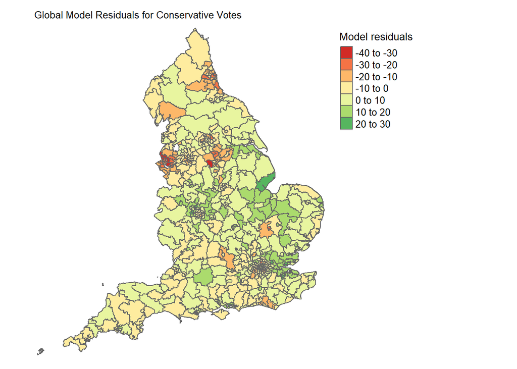

```r
# get model residuals for conservative model
resids <- residuals(global_conservative_lm)
# make new dataframe from constituency data and add residuals as new column
global_conservative_resids <- cbind(constituency_data, resids)

# plotting model residuals
map_resids_conservative <- tm_shape(global_conservative_resids) +
  tm_polygons(col = "resids",
              n = 6,
              title = "Model residuals")  +
  tm_layout(frame = FALSE,
            main.title = "Global Model Residuals for Conservative Votes",
            main.title.size = 0.8,
            legend.text.size = 0.8,
            legend.title.size = 1,
            legend.outside = TRUE)

map_resids_conservative
```

From the map, there seem to be spatial clustering in the residuals. These effects are especially prominent around urban areas like around Liverpool, Sunderland and Leeds. However, to make sure that the spatial clustering is significant we perform an autocorrelation test.

Before performing the spatial autocorrelation, we have to define neighbors.

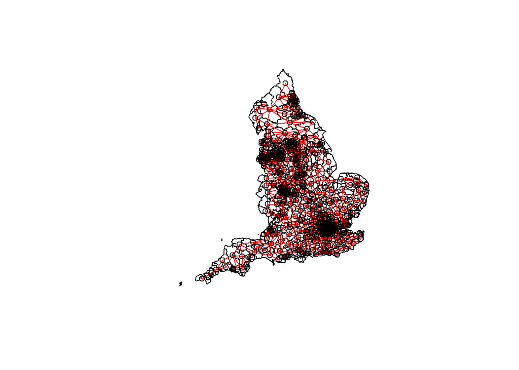

```r
# Define neighbor list (Queen adjacency neighborhood definition)
nb <- poly2nb(constituency_data)

# Simplify the boundaries to speed up the processing
constituencies_sm <- st_cast(st_simplify(constituency_data, dTolerance = 250), to = "MULTIPOLYGON")

# Define center of constituencies
constituency_centers <- st_coordinates(st_centroid(constituencies_sm$geometry))

# plot geometry and show the connections
plot(constituencies_sm$geometry); plot(nb, constituency_centers, col = "red", add = TRUE)
```

```r
# Add weights to each constituency according to distance to its neighbors. We use zero.policy = TRUE because there are islands that do not have any neighbors
lw <- nb2listw(nb, zero.policy = TRUE)
```

Then, we can perform the autocorrelation test with monte carlo simulation on the model residuals.

```r
# adding the residuals to the simplified sf data frame
constituencies_sm$global_conservative_lm <- residuals(global_conservative_lm)

# autocorrelation test for the Conservative party
moran.mc(constituencies_sm$global_conservative_lm, lw, 999, zero.policy = TRUE)
```

```
##
##  Monte-Carlo simulation of Moran I
##
## data:  constituencies_sm$global_conservative_lm
## weights: lw
## number of simulations + 1: 1000
##
## statistic = 0.59568, observed rank = 1000, p-value = 0.001
## alternative hypothesis: greater
```

From the Moran’s I test, we deduce that there appears to be spatial clustering of the model residuals, I = 0.60, p = 0.001.

```r
# get model residuals for labour model
resids <- residuals(global_labour_lm)
# make new dataframe from constituency data and add residuals as new column
global_labour_resids <- cbind(constituency_data, resids)
# plotting model residuals
map_resids_labour <- tm_shape(global_labour_resids) +
  tm_polygons(col = "resids",
              n = 6,
              title = "Model residuals")  +
  tm_layout(frame = FALSE,
            main.title = "Global Model Residuals for Labour Votes",
            main.title.size = 0.8,
            legend.text.size = 0.8,
            legend.title.size = 1,
            legend.outside = TRUE)
```

Again, it might seems as there is spatial clustering. So, we test for autocorrelation:

```r
# adding the residuals to the simplified sf data frame
constituencies_sm$global_labour_lm <- residuals(global_labour_lm)
# autocorrelation test for the Labour party
moran.mc(constituencies_sm$global_labour_lm, lw, 999, zero.policy = TRUE)
```

```
##
##  Monte-Carlo simulation of Moran I
##
## data:  constituencies_sm$global_labour_lm
## weights: lw
## number of simulations + 1: 1000
##
## statistic = 0.51533, observed rank = 1000, p-value = 0.001
## alternative hypothesis: greater
```

For the model on labour votes, the autocorrelation test points to a spatial clustering of the model residuals, Moran’s I = 0.52, p<0.001.

Lastly, we plot the model residuals for both global models to use in the rapport.

```
## Variable(s) "resids" contains positive and negative values, so midpoint is set to 0. Set midpoint = NA to show the full spectrum of the color palette.
## Variable(s) "resids" contains positive and negative values, so midpoint is set to 0. Set midpoint = NA to show the full spectrum of the color palette.
```

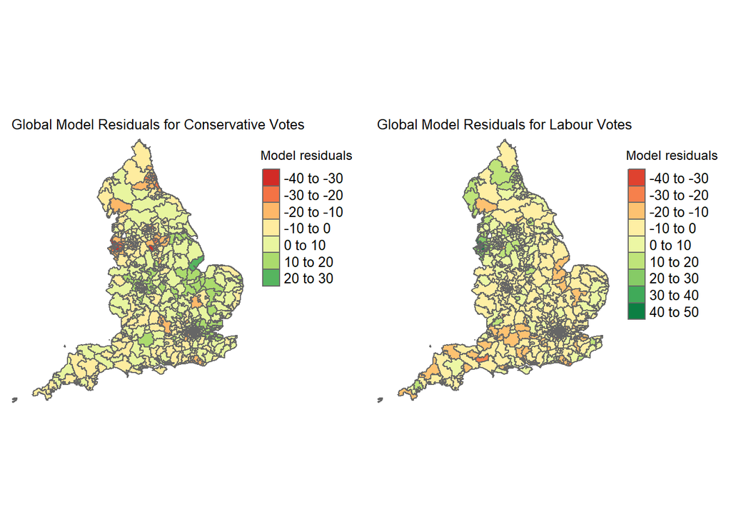

```r
# plotting residuals for both global models
tmap_arrange(map_resids_conservative, map_resids_labour, nrow = 1, asp = NA)
```

So, the fit of the model seem to vary across space indicating that a spatial regression is better fitted for this data.

## Spatial Regression Analysis:

Geographically weighted regression (GWR) is a spatial analysis technique in which the local relationship between non-static variables and a dependent variable is modelled by taking geographical location into account. This means that the model estimates depend on the location of the observations, which allows for discerning the importance of the predictors at different parliamentary constituencies in relation to how these affect voting patterns.  
When performing a GWR analysis, the specified bandwidth determines how neighboring constituencies are defined. Essentially, finding the bandwidth is like asking how many locations we should use to compute the varying slope as we move through the data space. We can choose either that the bandwidth is a given diameter around our focal point or it can be adaptive so that it takes the same number of observations for each focal point. The latter would mean that for denser areas, the bandwidth would be smaller. For this project, we chose to use an adapted bandwidth and to estimate the optimal bandwidth we used the function gwr.sel from the spgwr package. This performs cross validation and tries to minimize the root mean squared error (RMSE).To see how this defines our neighborhoods and how the distance varies, we plot the bandwidth distance for each constituency.  
Furthermore, we use a Gaussian kernel function which allows all locations to contribute to the model at focal point. However, nearer locations are weighted higher than distant locations.

As we are using an sf object, we also have to define a set of coordinates for each constituency so we first define the centroids for each constituency. Then, we find the optimal bandwidth for our model on conservative votes. Lastly, we use this to fit the model to the observations using the gwr function from the spgwr package.  
To test the validity of the spatial model, we examine the model residuals. Here, we perform an autocorrelation test to compare the results with the global regression using Moran’s I with Monte Carlo simulation.  
Lastly, we plot and examine the model coefficients and how they vary across English constituencies. From this, we cautiously draw inferences about how the relationship between voting patterns and demographic variables vary across space.

**GWR for Conservative Votes:**  
First, we perform our spatial analysis on the model on Conservative votes.

```r
# Define centroids of constituencies
constituency_centroids <- st_coordinates(st_centroid(constituency_data$geometry))
# check the crs
st_crs(constituency_data)
```

```
## Coordinate Reference System:
##   User input: OSGB 1936 / British National Grid
##   wkt:
## PROJCRS["OSGB 1936 / British National Grid",
##     BASEGEOGCRS["OSGB 1936",
##         DATUM["OSGB 1936",
##             ELLIPSOID["Airy 1830",6377563.396,299.3249646,
##                 LENGTHUNIT["metre",1]]],
##         PRIMEM["Greenwich",0,
##             ANGLEUNIT["degree",0.0174532925199433]],
##         ID["EPSG",4277]],
##     CONVERSION["British National Grid",
##         METHOD["Transverse Mercator",
##             ID["EPSG",9807]],
##         PARAMETER["Latitude of natural origin",49,
##             ANGLEUNIT["degree",0.0174532925199433],
##             ID["EPSG",8801]],
##         PARAMETER["Longitude of natural origin",-2,
##             ANGLEUNIT["degree",0.0174532925199433],
##             ID["EPSG",8802]],
##         PARAMETER["Scale factor at natural origin",0.9996012717,
##             SCALEUNIT["unity",1],
##             ID["EPSG",8805]],
##         PARAMETER["False easting",400000,
##             LENGTHUNIT["metre",1],
##             ID["EPSG",8806]],
##         PARAMETER["False northing",-100000,
##             LENGTHUNIT["metre",1],
##             ID["EPSG",8807]]],
##     CS[Cartesian,2],
##         AXIS["(E)",east,
##             ORDER[1],
##             LENGTHUNIT["metre",1]],
##         AXIS["(N)",north,
##             ORDER[2],
##             LENGTHUNIT["metre",1]],
##     USAGE[
##         SCOPE["Engineering survey, topographic mapping."],
##         AREA["United Kingdom (UK) - offshore to boundary of UKCS within 49Â°45'N to 61Â°N and 9Â°W to 2Â°E; onshore Great Britain (England, Wales and Scotland). Isle of Man onshore."],
##         BBOX[49.75,-9,61.01,2.01]],
##     ID["EPSG",27700]]
```

```r
# calculate optimal kernel bandwidth using the constituency coordinates defined when specifying neighborhoods, and adapting the kernel size according to density of areas
bw_conservative <- gwr.sel(perc_votes_conservative ~ pop_density + pubs_per_inhabitant + perc_white_pop + avg_age + avg_income, data = constituency_data, coords = constituency_centroids, adapt = T)
```

```
## Adaptive q: 0.381966 CV score: 47100.23
## Adaptive q: 0.618034 CV score: 51391.84
## Adaptive q: 0.236068 CV score: 43714.12
## Adaptive q: 0.145898 CV score: 39427.05
## Adaptive q: 0.09016994 CV score: 34362.75
## Adaptive q: 0.05572809 CV score: 31075.6
## Adaptive q: 0.03444185 CV score: 28843.51
## Adaptive q: 0.02128624 CV score: 27699.12
## Adaptive q: 0.01315562 CV score: 27437.36
## Adaptive q: 0.0109676 CV score: 28096.59
## Adaptive q: 0.01672285 CV score: 28007.64
## Adaptive q: 0.01451818 CV score: 27663.7
## Adaptive q: 0.01231987 CV score: 27495.99
## Adaptive q: 0.01306411 CV score: 27441.4
## Adaptive q: 0.01367607 CV score: 27447.79
## Adaptive q: 0.01332036 CV score: 27431.87
## Adaptive q: 0.01345623 CV score: 27432.44
## Adaptive q: 0.01337151 CV score: 27431.43
## Adaptive q: 0.01341221 CV score: 27431.62
## Adaptive q: 0.01337151 CV score: 27431.43
```

```r
# fitting the model for conservative votes using Gaussian weight
gwr_model_conservative = gwr(perc_votes_conservative ~ pop_density + pubs_per_inhabitant
                             + perc_white_pop + avg_age + avg_income,
                             data = constituency_data,
                             coords = constituency_centroids,
                             adapt=bw_conservative,
                             hatmatrix=TRUE,
                             se.fit=TRUE,
                             gweight=gwr.Gauss)

# check model summary
gwr_model_conservative
```

```
## Call:
## gwr(formula = perc_votes_conservative ~ pop_density + pubs_per_inhabitant +
##     perc_white_pop + avg_age + avg_income, data = constituency_data,
##     coords = constituency_centroids, gweight = gwr.Gauss, adapt = bw_conservative,
##     hatmatrix = TRUE, se.fit = TRUE)
## Kernel function: gwr.Gauss
## Adaptive quantile: 0.01337151 (about 7 of 531 data points)
## Summary of GWR coefficient estimates at data points:
##                            Min.     1st Qu.      Median     3rd Qu.        Max.
## X.Intercept.        -3.6436e+02 -5.6357e+01 -3.4874e+01 -1.9682e+01  1.6905e+02
## pop_density         -3.1667e+01 -8.9918e+00 -5.3281e+00 -3.3649e+00  7.8101e+00
## pubs_per_inhabitant -1.9786e+01 -3.5342e+00 -8.0711e-01  2.5996e+00  1.2892e+01
## perc_white_pop      -2.5861e+02 -3.7384e+00  1.9746e+01  3.9615e+01  3.7803e+02
## avg_age             -1.1635e+00  1.2197e+00  1.8263e+00  2.3373e+00  6.5471e+00
## avg_income          -2.9479e-03 -4.3731e-04 -5.8955e-05  1.5803e-04  1.4534e-03
##                       Global
## X.Intercept.        -35.0865
## pop_density          -7.3177
## pubs_per_inhabitant  -4.0747
## perc_white_pop        1.8133
## avg_age               1.8416
## avg_income            0.0003
## Number of data points: 531
## Effective number of parameters (residual: 2traceS - traceS'S): 200.4654
## Effective degrees of freedom (residual: 2traceS - traceS'S): 330.5346
## Sigma (residual: 2traceS - traceS'S): 6.144626
## Effective number of parameters (model: traceS): 151.9458
## Effective degrees of freedom (model: traceS): 379.0542
## Sigma (model: traceS): 5.737904
## Sigma (ML): 4.847934
## AICc (GWR p. 61, eq 2.33; p. 96, eq. 4.21): 3614.118
## AIC (GWR p. 96, eq. 4.22): 3335.281
## Residual sum of squares: 12479.81
## Quasi-global R2: 0.9056418
```

```r
# saving results as a data frame
results_conservative <-as.data.frame(gwr_model_conservative$SDF)
# checking names
names(results_conservative)
```

```
##  [1] "sum.w"                      "X.Intercept."
##  [3] "pop_density"                "pubs_per_inhabitant"
##  [5] "perc_white_pop"             "avg_age"
##  [7] "avg_income"                 "X.Intercept._se"
##  [9] "pop_density_se"             "pubs_per_inhabitant_se"
## [11] "perc_white_pop_se"          "avg_age_se"
## [13] "avg_income_se"              "gwr.e"
## [15] "pred"                       "pred.se"
## [17] "localR2"                    "X.Intercept._se_EDF"
## [19] "pop_density_se_EDF"         "pubs_per_inhabitant_se_EDF"
## [21] "perc_white_pop_se_EDF"      "avg_age_se_EDF"
## [23] "avg_income_se_EDF"          "pred.se.1"
## [25] "X"                          "Y"
```

```r
# merging the results data frame with the sf data frame
gwr_conservative_merged <- cbind(constituency_data, as.matrix(results_conservative))

# save adaptive bandwidth to results data
gwr_conservative_merged$bwadapt <- gwr_model_conservative$bandwidth
```

```r
# plotting bandwidth distance for each constituency
bwadapt_conservative <- tm_shape(gwr_conservative_merged,
                                 unit = "km") + # using km for the map scale
  tm_polygons(col = "bwadapt",
              style = "quantile",
              palette = "Blues",
              border.alpha = 0,
              title = "Distance (meters)") +
  # adding a map scale bar
  tm_scale_bar(breaks = c(0, 50, 100, 150, 200),
               size = 1,
               position = c("right", "bottom")) +
  # adding compass
  tm_compass(type = "4star",
             position = c("left", "top")) +
  tm_layout(main.title = "GWR bandwidth for Conservative model",
            main.title.size = 0.8,
            legend.outside = TRUE)
```

Here, it is quite apparent that the bigger cities have smaller bandwidths compared to rural areas.

Lastly, we explore the spatial variability in model coefficients as this will give us an intuition of how these demographic variables effect voting patterns differently across constituencies.

```
## Variable(s) "perc_white_pop.1" contains positive and negative values, so midpoint is set to 0. Set midpoint = NA to show the full spectrum of the color palette.
```

```
## Some legend labels were too wide. These labels have been resized to 0.64, 0.73, 0.71. Increase legend.width (argument of tm_layout) to make the legend wider and therefore the labels larger.
```

```
## Variable(s) "pubs_per_inhabitant.1" contains positive and negative values, so midpoint is set to 0. Set midpoint = NA to show the full spectrum of the color palette.
```

```
## Some legend labels were too wide. These labels have been resized to 0.64, 0.69, 0.73, 0.71. Increase legend.width (argument of tm_layout) to make the legend wider and therefore the labels larger.
```

```
## Variable(s) "pop_density.1" contains positive and negative values, so midpoint is set to 0. Set midpoint = NA to show the full spectrum of the color palette.
```

```
## Legend labels were too wide. The labels have been resized to 0.59, 0.64, 0.69, 0.69, 0.73. Increase legend.width (argument of tm_layout) to make the legend wider and therefore the labels larger.
```

```
## Variable(s) "avg_age.1" contains positive and negative values, so midpoint is set to 0. Set midpoint = NA to show the full spectrum of the color palette.
```

```
## Legend labels were too wide. The labels have been resized to 0.62, 0.65, 0.65, 0.65, 0.65. Increase legend.width (argument of tm_layout) to make the legend wider and therefore the labels larger.
```

```
## Variable(s) "avg_income.1" contains positive and negative values, so midpoint is set to 0. Set midpoint = NA to show the full spectrum of the color palette.
```

```
## Legend labels were too wide. The labels have been resized to 0.51, 0.51, 0.53, 0.55, 0.55. Increase legend.width (argument of tm_layout) to make the legend wider and therefore the labels larger.
```

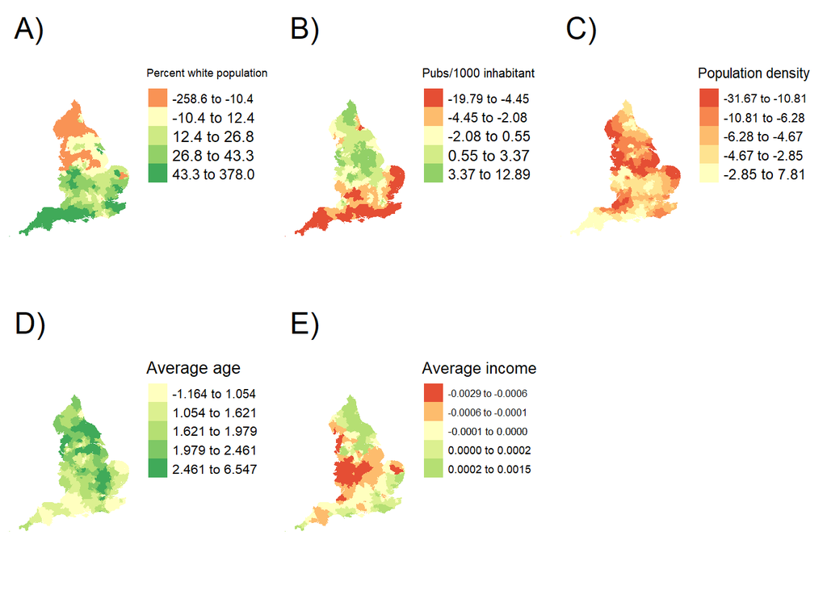

```r
# map of coefficients for percent white population
map1 <- tm_shape(gwr_conservative_merged) +
  tm_fill("perc_white_pop.1",
          n = 5,
          style = "quantile",
          title = "Percent white population")  +
  tm_layout(frame = FALSE,
            legend.text.size = 0.8,
            legend.title.size = 1,
            legend.outside = TRUE,
            legend.outside.size = 0.5,
            main.title = "A)")

# map of coefficients for pubs per inhabitant
map2 <- tm_shape(gwr_conservative_merged) +
  tm_fill("pubs_per_inhabitant.1",
          n = 5,
          style = "quantile",
          title = "Pubs/1000 inhabitant")  +
  tm_layout(frame = FALSE,
            legend.text.size = 0.8,
            legend.title.size = 1,
            legend.outside = TRUE,
            legend.outside.size = 0.5,
            main.title = "B)")

# map of coefficients for population density
map3 <- tm_shape(gwr_conservative_merged) +
  tm_fill("pop_density.1",
          n = 5,
          style = "quantile",
          title = "Population density")  +
  tm_layout(frame = FALSE,
            legend.text.size = 0.8,
            legend.title.size = 1,
            legend.outside = TRUE,
            legend.outside.size = 0.5,
            main.title = "C)")

# map of coefficients for average age
map4 <- tm_shape(gwr_conservative_merged) +
  tm_fill("avg_age.1",
          n = 5,
          style = "quantile",
          title = "Average age")  +
  tm_layout(frame = FALSE,
            legend.text.size = 0.8,
            legend.title.size = 1,
            legend.outside = TRUE,
            legend.outside.size = 0.5,
            main.title = "D)")

# map of coefficients for average income
map5 <- tm_shape(gwr_conservative_merged) +
  tm_fill("avg_income.1",
          n = 5,
          style = "quantile",
          title = "Average income")  +
  tm_layout(frame = FALSE,
            legend.text.size = 0.8,
            legend.title.size = 1,
            legend.outside = TRUE,
            legend.outside.size = 0.5,
            main.title = "E)")

# print all maps together
tmap_arrange(map1,map2,map3, map4, map5, nrow=2)
```

To compare with the global regression, we also plot the GWR model residuals and perform a moran’s I test.

```
## Variable(s) "gwr.e" contains positive and negative values, so midpoint is set to 0. Set midpoint = NA to show the full spectrum of the color palette.
```

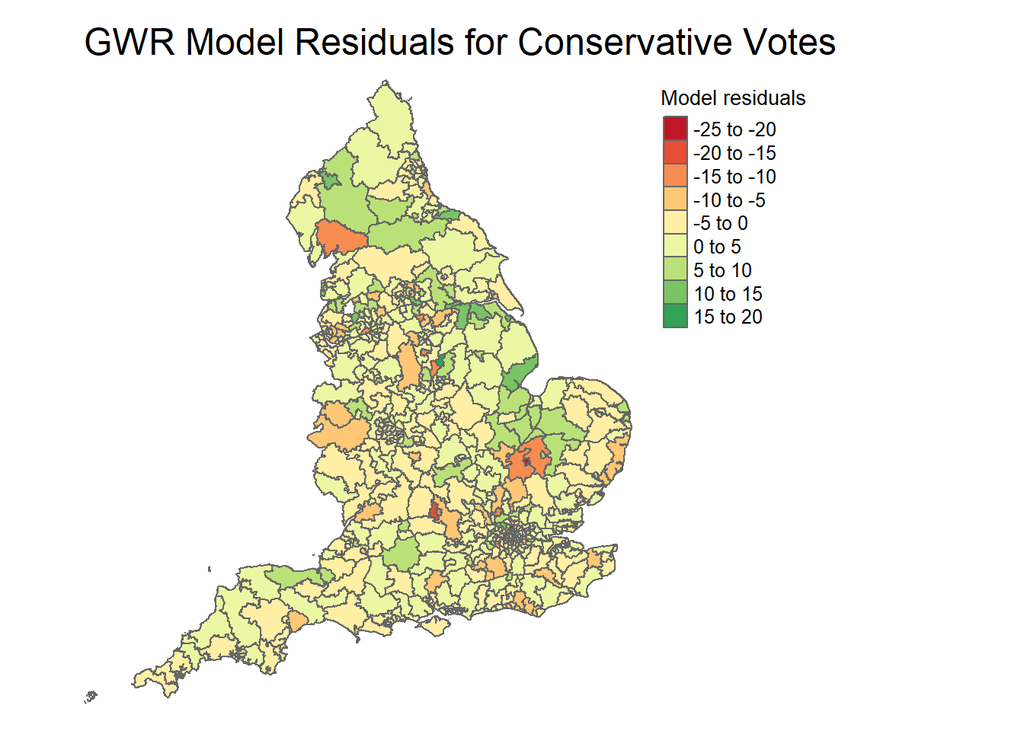

```r
# plotting model residuals
tm_shape(gwr_conservative_merged) +
  tm_polygons(col = "gwr.e",
              n = 6,
              title = "Model residuals")  +
  tm_layout(frame = FALSE,
            main.title = "GWR Model Residuals for Conservative Votes",
            legend.text.size = 0.8,
            legend.title.size = 1,
            legend.outside = TRUE)
```

```r
# To test whether this distribution is random, we perform Moran's I autocorrelation test
moran.mc(gwr_conservative_merged$gwr.e, lw, 999, zero.policy = TRUE)
```

```
##
##  Monte-Carlo simulation of Moran I
##
## data:  gwr_conservative_merged$gwr.e
## weights: lw
## number of simulations + 1: 1000
##
## statistic = 0.12598, observed rank = 1000, p-value = 0.001
## alternative hypothesis: greater
```

Here, we see that the spatial clustering is still significant but also remarkably less than for the global model. Moran’s I for the GWR for Conservative votes is 0.13 compared to 0.60 for the global model.

**GWR for Labour Votes:**  
Then, we define a similar GWR for our model on votes for the Labour Party.

```r
# calculate optimal kernel bandwidth using the constituency coordinates defined when specifying neighborhoods, and adapting the kernel size according to density of areas
bw <- gwr.sel(perc_votes_labour ~ pop_density + pubs_per_inhabitant + perc_white_pop + avg_age + avg_income, data = constituency_data, coords = constituency_centroids, adapt = T)
```

```
## Adaptive q: 0.381966 CV score: 42768.79
## Adaptive q: 0.618034 CV score: 48985.67
## Adaptive q: 0.236068 CV score: 39034.75
## Adaptive q: 0.145898 CV score: 35763.69
## Adaptive q: 0.09016994 CV score: 31874.25
## Adaptive q: 0.05572809 CV score: 30044.99
## Adaptive q: 0.03444185 CV score: 28681.4
## Adaptive q: 0.02128624 CV score: 29741.29
## Adaptive q: 0.03745722 CV score: 28774.06
## Adaptive q: 0.03371701 CV score: 28719.67
## Adaptive q: 0.03526151 CV score: 28655.9
## Adaptive q: 0.0361002 CV score: 28679.75
## Adaptive q: 0.0353022 CV score: 28655.65
## Adaptive q: 0.03535217 CV score: 28655.46
## Adaptive q: 0.03563789 CV score: 28656.72
## Adaptive q: 0.03540009 CV score: 28655.4
## Adaptive q: 0.03544078 CV score: 28655.44
## Adaptive q: 0.03540009 CV score: 28655.4
```

```r
# fitting the model for conservative votes using Gaussian weight
gwr_model_labour = gwr(perc_votes_labour ~ pop_density + pubs_per_inhabitant
                       + perc_white_pop + avg_age + avg_income,
                       data = constituency_data,
                       coords = constituency_centroids,
                       adapt=bw,
                       hatmatrix=TRUE,
                       se.fit=TRUE,
                       gweight=gwr.Gauss)

# check model summary
gwr_model_labour
```

```
## Call:
## gwr(formula = perc_votes_labour ~ pop_density + pubs_per_inhabitant +
##     perc_white_pop + avg_age + avg_income, data = constituency_data,
##     coords = constituency_centroids, gweight = gwr.Gauss, adapt = bw,
##     hatmatrix = TRUE, se.fit = TRUE)
## Kernel function: gwr.Gauss
## Adaptive quantile: 0.03540009 (about 18 of 531 data points)
## Summary of GWR coefficient estimates at data points:
##                            Min.     1st Qu.      Median     3rd Qu.        Max.
## X.Intercept.         6.1190e+01  1.2648e+02  1.4398e+02  1.5521e+02  1.8806e+02
## pop_density          7.8741e-01  4.6963e+00  5.7170e+00  7.0039e+00  1.9384e+01
## pubs_per_inhabitant -5.5712e+00 -3.9927e-01  7.6612e-01  2.2073e+00  7.2304e+00
## perc_white_pop      -5.9721e+01 -4.0570e+01 -3.0029e+01 -1.1055e+01  8.9770e+01
## avg_age             -3.7347e+00 -2.2728e+00 -1.9929e+00 -1.6163e+00 -6.4870e-01
## avg_income          -8.6186e-04 -4.7624e-04 -3.1618e-04 -1.4326e-04  6.0736e-04
##                       Global
## X.Intercept.        143.1671
## pop_density           7.8511
## pubs_per_inhabitant   3.0264
## perc_white_pop       -9.0687
## avg_age              -1.9988
## avg_income           -0.0007
## Number of data points: 531
## Effective number of parameters (residual: 2traceS - traceS'S): 91.56542
## Effective degrees of freedom (residual: 2traceS - traceS'S): 439.4346
## Sigma (residual: 2traceS - traceS'S): 6.997308
## Effective number of parameters (model: traceS): 67.73444
## Effective degrees of freedom (model: traceS): 463.2656
## Sigma (model: traceS): 6.814957
## Sigma (ML): 6.365476
## AICc (GWR p. 61, eq 2.33; p. 96, eq. 4.21): 3630.808
## AIC (GWR p. 96, eq. 4.22): 3540.291
## Residual sum of squares: 21515.74
## Quasi-global R2: 0.8679958
```

```r
# saving results as a data frame
results_labour <-as.data.frame(gwr_model_labour$SDF)
# checking names
names(results_labour)
```

```
##  [1] "sum.w"                      "X.Intercept."
##  [3] "pop_density"                "pubs_per_inhabitant"
##  [5] "perc_white_pop"             "avg_age"
##  [7] "avg_income"                 "X.Intercept._se"
##  [9] "pop_density_se"             "pubs_per_inhabitant_se"
## [11] "perc_white_pop_se"          "avg_age_se"
## [13] "avg_income_se"              "gwr.e"
## [15] "pred"                       "pred.se"
## [17] "localR2"                    "X.Intercept._se_EDF"
## [19] "pop_density_se_EDF"         "pubs_per_inhabitant_se_EDF"
## [21] "perc_white_pop_se_EDF"      "avg_age_se_EDF"
## [23] "avg_income_se_EDF"          "pred.se.1"
## [25] "X"                          "Y"
```

```r
# merging the results data frame with the sf data frame
gwr_labour_merged <- cbind(constituency_data, as.matrix(results_labour))

# save adaptive bandwidth to results data
gwr_labour_merged$bwadapt <- gwr_model_labour$bandwidth
```

```r
# plotting bandwidth distance for each constituency
bwadapt_labour <- tm_shape(gwr_labour_merged, unit = "km") +
  tm_polygons(col = "bwadapt",
              style = "quantile",
              palette = "Reds",
              border.alpha = 0,
              title = "Distance (meters)") +
  tm_scale_bar(breaks = c(0, 50, 100, 150, 200),
               size = 10,
               position = c("right", "bottom")) +
  tm_compass(type = "4star",
             position = c("left", "top")) +
  tm_layout(main.title = "GWR bandwidth for Labour model",
            main.title.size = 0.8,
            legend.outside = TRUE)
```

We plot the bandwidth distances for each constituencies for each model.

```
## Legend labels were too wide. The labels have been resized to 0.54, 0.50, 0.50, 0.50, 0.50. Increase legend.width (argument of tm_layout) to make the legend wider and therefore the labels larger.
```

```
## Legend labels were too wide. The labels have been resized to 0.54, 0.50, 0.50, 0.50, 0.47. Increase legend.width (argument of tm_layout) to make the legend wider and therefore the labels larger.
```

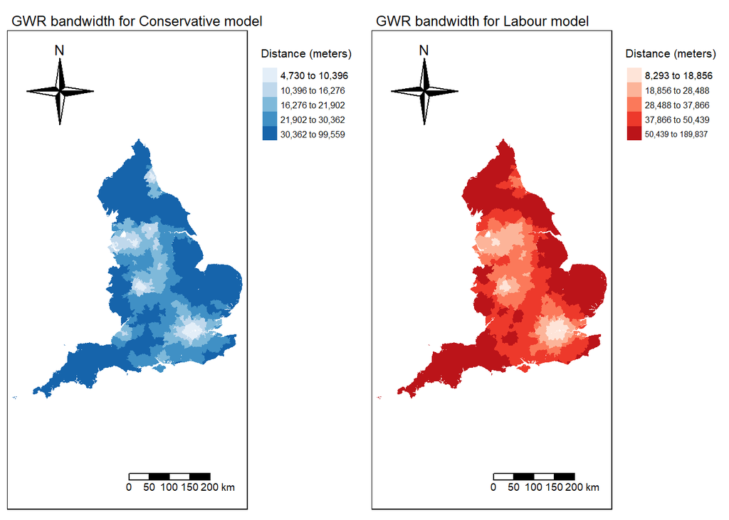

```r
# plotting bandwith for both models
tmap_arrange(bwadapt_conservative, bwadapt_labour, nrow = 1)
```

```
## Variable(s) "perc_white_pop.1" contains positive and negative values, so midpoint is set to 0. Set midpoint = NA to show the full spectrum of the color palette.
```

```
## Legend labels were too wide. The labels have been resized to 0.59, 0.59, 0.59, 0.64, 0.67. Increase legend.width (argument of tm_layout) to make the legend wider and therefore the labels larger.
```

```
## Variable(s) "pubs_per_inhabitant.1" contains positive and negative values, so midpoint is set to 0. Set midpoint = NA to show the full spectrum of the color palette.
```

```
## Legend labels were too wide. The labels have been resized to 0.59, 0.62, 0.65, 0.65, 0.65. Increase legend.width (argument of tm_layout) to make the legend wider and therefore the labels larger.
```

```
## Legend labels were too wide. The labels have been resized to 0.59, 0.59, 0.59, 0.59, 0.59. Increase legend.width (argument of tm_layout) to make the legend wider and therefore the labels larger.
```

```
## Variable(s) "avg_income.1" contains positive and negative values, so midpoint is set to 0. Set midpoint = NA to show the full spectrum of the color palette.
```

```
## Legend labels were too wide. The labels have been resized to 0.51, 0.51, 0.51, 0.51, 0.53. Increase legend.width (argument of tm_layout) to make the legend wider and therefore the labels larger.
```

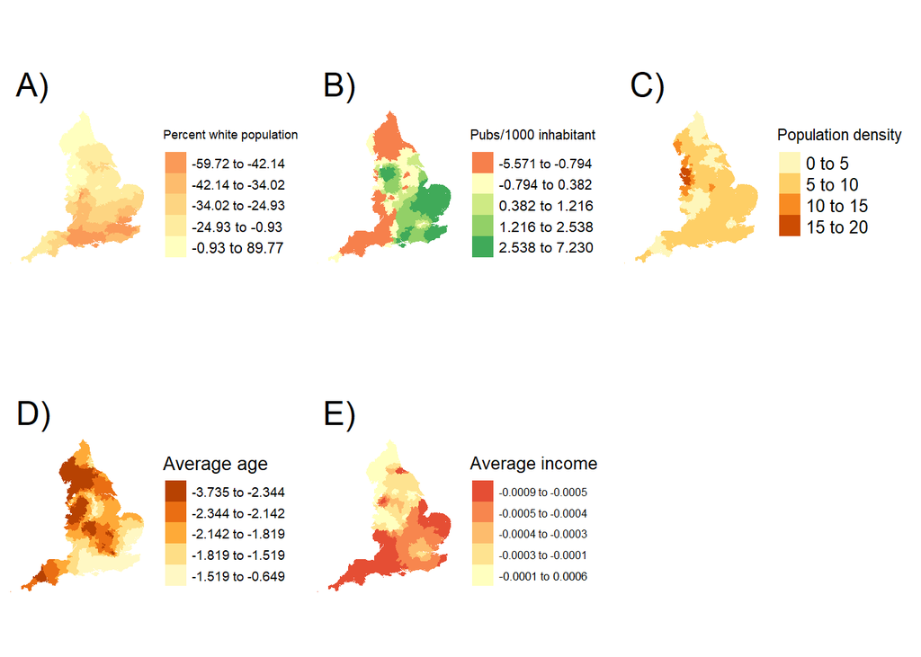

```r
# map of coefficients for percent white population
map6 <- tm_shape(gwr_labour_merged) +
  tm_fill("perc_white_pop.1",
          n = 5,
          style = "quantile",
          title = "Percent white population")  +
  tm_layout(frame = FALSE,
            legend.text.size = 0.8,
            legend.title.size = 1,
            legend.outside = TRUE,
            legend.outside.size = 0.5,
            main.title = "A)")

# map for pubs per inhabitant coefficients
map7 <- tm_shape(gwr_labour_merged) +
  tm_fill("pubs_per_inhabitant.1",
          n = 5,
          style = "quantile",
          title = "Pubs/1000 inhabitant")  +
  tm_layout(frame = FALSE,
            legend.text.size = 0.8,
            legend.title.size = 1,
            legend.outside = TRUE,
            legend.outside.size = 0.5,
            main.title = "B)")

# map for population density coefficients
map8 <- tm_shape(gwr_labour_merged) +
  tm_fill("pop_density.1",
          n = 5,
          title = "Population density")  +
  tm_layout(frame = FALSE,
            legend.text.size = 0.8,
            legend.title.size = 1,
            legend.outside = TRUE,
            legend.outside.size = 0.5,
            main.title = "C)")

# map for average age coefficients
map9 <- tm_shape(gwr_labour_merged) +
  tm_fill("avg_age.1",
          n = 5,
          style = "quantile",
          title = "Average age")  +
  tm_layout(frame = FALSE,
            legend.text.size = 0.8,
            legend.title.size = 1,
            legend.outside = TRUE,
            legend.outside.size = 0.5,
            main.title = "D)")

# map for average income coefficients
map10 <- tm_shape(gwr_labour_merged) +
  tm_fill("avg_income.1",
          n = 5,
          style = "quantile",
          title = "Average income")  +
  tm_layout(frame = FALSE,
            legend.text.size = 0.8,
            legend.title.size = 1,
            legend.outside = TRUE,
            legend.outside.size = 0.5,
            main.title = "E)")

# print all maps together
tmap_arrange(map6, map7, map8, map9, map10, nrow=2, asp = NA)
```

To compare with the global regression, we also plot the model residuals and perform a moran’s I test.

```
## Variable(s) "gwr.e" contains positive and negative values, so midpoint is set to 0. Set midpoint = NA to show the full spectrum of the color palette.
```

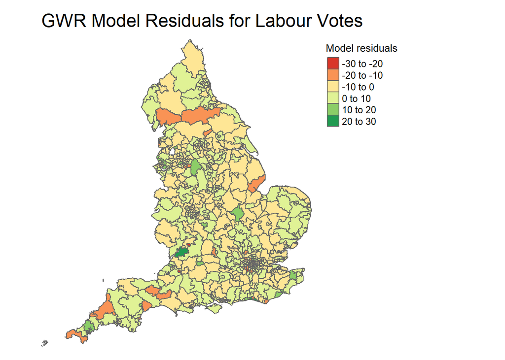

```r
# plotting model residuals
tm_shape(gwr_labour_merged) +
  tm_polygons(col = "gwr.e",
              n = 6,
              title = "Model residuals")  +
  tm_layout(frame = FALSE,
            main.title = "GWR Model Residuals for Labour Votes",
            legend.text.size = 0.8,
            legend.title.size = 1,
            legend.outside = TRUE)
```

```r
# To test whether this distribution is random, we perform Moran's I autocorrelation test
moran.mc(gwr_labour_merged$gwr.e, lw, 999, zero.policy = TRUE)
```

[output not shown]

As with the Conservative model, we observe that the spatial clustering is still significant but reduced compared to the global model. Moran’s I for the GWR for Labour votes is 0.10 compared to 0.52 for the global model.

For our rapport, we want to focus on the spatial variation of the coefficient of pubs per 1000 inhabitants. Therefore, we plot the coefficients for this variable for both models.

```
## Variable(s) "pubs_per_inhabitant.1" contains positive and negative values, so midpoint is set to 0. Set midpoint = NA to show the full spectrum of the color palette.
## Variable(s) "pubs_per_inhabitant.1" contains positive and negative values, so midpoint is set to 0. Set midpoint = NA to show the full spectrum of the color palette.
```

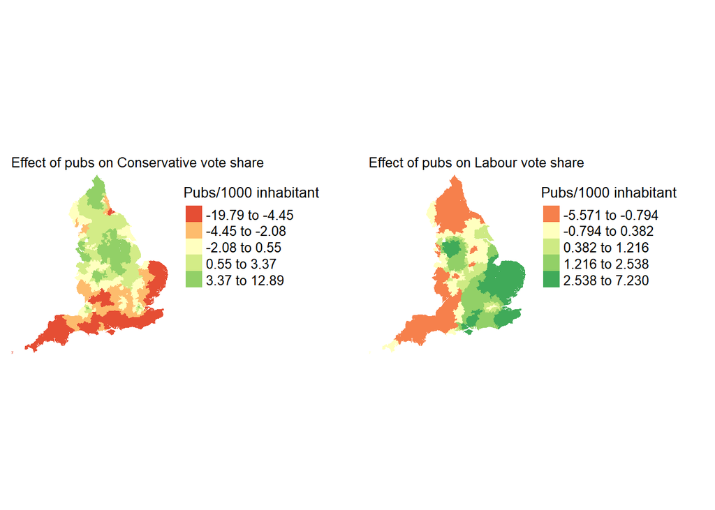

```r
# mapping pub coefficient for conservative model
pubs_conservative <- tm_shape(gwr_conservative_merged) +
  tm_fill("pubs_per_inhabitant.1",
          n = 5,
          style = "quantile",
          title = "Pubs/1000 inhabitant")  +
  tm_layout(frame = FALSE,
            legend.text.size = 0.8,
            legend.title.size = 1,
            legend.outside = TRUE,
            legend.outside.size = 0.5,
            main.title = "Effect of pubs on Conservative vote share",
            main.title.size = 0.8)

# mapping pub coefficient for labour model
pubs_labour <- tm_shape(gwr_labour_merged) +
  tm_fill("pubs_per_inhabitant.1",
          n = 5,
          style = "quantile",
          title = "Pubs/1000 inhabitant")  +
  tm_layout(frame = FALSE,
            legend.text.size = 0.8,
            legend.title.size = 1,
            legend.outside = TRUE,
            legend.outside.size = 0.5,
            main.title = "Effect of pubs on Labour vote share",
            main.title.size = 0.8)

# plotting the two maps together
tmap_arrange(pubs_conservative, pubs_labour, nrow = 1, asp = NA)
```

Based on our spatial regression analysis, we can conclude that the relationship between voting patterns and demographics is sensitive to where you live in England.  
So, space mattered to the results of the UK general election in 2019.